# Overview

Description: This assignment builds off of the examples from Lecture 3 on understanding price gouging by leveraging AI agents. You will choose a new product idea: you can be as creative as you want or pick a product you’d be interested in forming a startup around / launching at an existing company. Then construct a focus group of AI agents to help inform your decision about whether to introduce the product, how to market it, how to deal with any concerns. The deliverables are a written report (just 1 page single spaced, or 2 double spaced), plus supporting materials and a Google Sheet summarizing your work. If you use ChatGPT please also include a shareable link to your prompting thread.

```python
import os
from openai import OpenAI
import requests
from IPython.display import display, Image
import pandas as pd
```

# Part 1: Invention

Invent a new product or service for some market you are interested in. It can be completely impractical or fantastical - or alternatively very relevant to your work. Perhaps make an image of your product if appropriate.

## Invent the product

```python
# Define the prompt to generate a product idea
product_prompt = """
Generate a creative and innovative product for teaching dogs how to learn to play guitar.
Provide a brief description of the product, its target market, and its unique selling points.
"""

client = OpenAI(api_key=os.getenv("OPENAI_API_KEY"))

product_response = client.chat.completions.create(
    model="gpt-4o",
    messages=[
        {"role": "user", "content": product_prompt}
    ],
    temperature=1
)

product_idea = product_response.choices[0].message.content
print("Product Idea:", product_idea)
```

```
Product Idea: **Product Name:** PupStrings: Canine Guitar Learning Kit

**Description:**
PupStrings is a groundbreaking educational kit specifically designed to teach dogs the basics of playing the guitar. The kit features a specially designed multi-sensory guitar prototype adapted for canine anatomy, complete with paw-friendly strumming pads and scent-emitting fret markers. The learnin…

**Key Components:**
1. **Canine-Adapted Guitar:** A lightweight, durable guitar with enlarged tactile strumming surfaces and vibration feedback to help dogs understand when a correct chord is played.

2. **Interactive Learning App:** This app connects via Bluetooth, providing step-by-step lessons, dynamic progress tracking, and customizable training schedules. It also offers an inclusive community for pet owners to share tips and stories.

3. **Reward-Based Program:** Integrates with treat-dispensing technology to incentivize dogs as they reach learning milestones, reinforcing positive behavior through delicious rewards.

4. **Scent-Emitting Fret Markers:** Specially developed to appeal to a dog's powerful sense of smell, these scented markers guide the dog’s paws to the correct strings, providing both tactile and olfactory cues for learning chords.

5. **Eco-Friendly Design:** Made from sustainable materials, the guitar is not only eco-friendly but also chew-resistant, ensuring both safety and durability.

**Target Market:**
PupStrings primarily targets dog owners who are enthusiastic about enriching their pets' cognitive and physical activities. Ideal customers include pet owners with a passion for music, tech-savvy individuals who enjoy connecting their pets to smart devices, and those seeking innovative and interacti…

**Unique Selling Points:**
- **Innovative Approach:** First of its kind to fuse musical training with pet-friendly technology.
- **Multi-Sensory Learning:** Utilizes touch, sound, and scent to create a truly engaging learning experience for dogs.
- **Smart Integration:** The integrated app and AI feedback provide a modern and novel way for dogs to interact with music, offering insights similar to human music classes.
- **Enrichment and Bonding:** Strengthens the bond between pet and owner through shared musical activities and learning, while also enhancing the dog's cognitive skills and providing physical exercise.

PupStrings offers an unforgettable experience, transforming the idea of dog training and entertainment while fostering a unique talent we didn't know our furry friends could possess!
```

```python
# Save the product idea to a file
with open("product_idea.txt", "w") as file:
    file.write(product_idea)
```

## Create an image of the product

```python
image_prompt_generation_prompt = f"""
Create a detailed prompt to generate an image for the following product idea: {product_idea}
The prompt should include specific details about the product's appearance, setting, and any other relevant visual elements.
The dog should be a corgi.
"""

client = OpenAI(api_key=os.getenv("OPENAI_API_KEY"))

image_prompt_response = client.chat.completions.create(
    model="gpt-4o",
    messages=[
        {"role": "user", "content": image_prompt_generation_prompt}
    ],
    temperature=0.7
)

image_prompt = image_prompt_response.choices[0].message.content
print("Image Prompt:", image_prompt)
```

```
Image Prompt: **Prompt for Image Generation:**

Create an imaginative and engaging scene featuring the **PupStrings: Canine Guitar Learning Kit**. In the center of the image, showcase a cheerful corgi, eagerly engaged with the specially designed canine-adapted guitar. The guitar should be lightweight and visually appealing, with enlarged, colorfu…

Highlight the innovative scent-emitting fret markers by illustrating small, visible scent trails, perhaps in pastel colors, emanating from them, guiding the corgi's paws to the correct strings. Capture the moment when the corgi successfully strums a chord, with gentle vibration lines to indicate the…

In the background, feature a cozy and modern living room setting, where a tablet or smartphone is prominently displayed on a stand, showing the interface of the interactive learning app. The app screen should depict a friendly, animated dog trainer providing step-by-step video instructions, alongsid…

Include a small, sleek treat-dispensing device nearby, releasing a treat as a reward for the corgi's successful chord play, reinforcing positive behavior. The treats should be visible in mid-air, adding a dynamic element to the scene.

Incorporate subtle elements that emphasize the community aspect of the product, such as a bulletin board or digital screen showing user-shared photos of other dogs playing the guitar, accompanied by encouraging comments or tips.

Emphasize warmth and joy in the overall ambiance of the image, using natural light streaming through a window to create a sense of an inviting and lively environment. Add small touches of musical notes floating around the corgi to symbolize the musical learning journey, enhancing the whimsical and i…
```

```python
client = OpenAI(api_key=os.getenv("OPENAI_API_KEY"))

response = client.images.generate(
    model="dall-e-3",
    prompt=image_prompt,
    size="1024x1024",
    quality="standard",
    n=1
)

# Display image directly from URL
display(Image(url=response.data[0].url))

# Save image to a file
image_path = "product_image.jpg"
with open(image_path, "wb") as file:
    file.write(requests.get(response.data[0].url).content)
```

[figure not shown]

[figure not shown]

# Part 2: Persona Agents

You then will create potential "persona" customers, decision-makers or stake-holders and "interview" them. Give them attributes that might be relevant to how they think and feel about your product. You should have at least four agent personas. This should be one tab in your Google Sheet labeled "Agents".

## Link to Google Sheet

https://docs.google.com/spreadsheets/d/1yEDaUTlUSjo89B0ANxDpxEfP-sso9Hl-gmnshqTy2vw/edit?gid=0#gid=0

## Create attributes

```python
attribute_prompt = f"""
Create a list of 10 customer attributes which may impact buying decisions for the following product idea: {product_idea}.
Ensure more than half of the attributes are general demographic information, and the rest are specific to the product.
Return the attributes in a comma separated list with no other text.
"""

client = OpenAI(api_key=os.getenv("OPENAI_API_KEY"))

attribute_response = client.chat.completions.create(
    model="gpt-4o",
    messages=[
        {"role": "user", "content": attribute_prompt}
    ],
    temperature=0.7
)

attributes = attribute_response.choices[0].message.content
print("Attributes:", attributes)
```

```
Attributes: Age of the dog owner, income level of the dog owner, education level of the dog owner, location of residence, household size, pet ownership experience, interest in music, technology adoption level, frequency of purchasing pet products, willingness to spend on pet education and entertainm…
```

## Create personas

```python
persona_prompt = f"""
Create a list of 25 personas based on the following customer attributes for the product idea: {product_idea}.
{attributes}
Ensure the personas are diverse and include a mix of general demographic information and specific product preferences.
Return the personas in a comma separated list with the person's name as the first column and the attributes as the following columns.
Include a header row with the attribute names.
"""

client = OpenAI(api_key=os.getenv("OPENAI_API_KEY"))

persona_response = client.chat.completions.create(
    model="gpt-4o",
    messages=[
        {"role": "user", "content": persona_prompt}
    ],
    temperature=0.7
)

personas = persona_response.choices[0].message.content
print("Personas:", personas)
```

```
Personas: Name, Age of Dog Owner, Income Level, Education Level, Location of Residence, Household Size, Pet Ownership Experience, Interest in Music, Technology Adoption Level, Frequency of Purchasing Pet Products, Willingness to Spend on Pet Education and Entertainment
John Doe, 34, $75,000, Bachelor's, Urban, 2, Moderate, High, High, Monthly, High
Jane Smith, 28, $65,000, Master's, Suburban, 3, High, Moderate, High, Bi-weekly, Moderate
Emily Johnson, 42, $90,000, Bachelor's, Rural, 4, High, High, Moderate, Monthly, High
Mike Brown, 55, $120,000, Doctorate, Urban, 1, Low, Low, High, Quarterly, Moderate
Sarah Davis, 30, $85,000, Master's, Suburban, 2, Moderate, High, Moderate, Monthly, High
Chris Wilson, 25, $50,000, Bachelor's, Urban, 1, High, High, High, Bi-weekly, High
Anna Martinez, 38, $100,000, Bachelor's, Rural, 5, Moderate, Moderate, Moderate, Monthly, Moderate
David Anderson, 47, $110,000, Master's, Suburban, 3, Low, High, High, Monthly, High
Laura Thomas, 31, $70,000, Bachelor's, Urban, 2, High, Moderate, High, Weekly, Moderate
James Taylor, 60, $130,000, Doctorate, Rural, 1, Moderate, Low, Moderate, Quarterly, Low
Olivia Moore, 29, $55,000, Bachelor's, Suburban, 3, High, High, High, Bi-weekly, High
Daniel White, 40, $95,000, Master's, Urban, 4, Low, Moderate, Moderate, Monthly, Moderate
Sophia Harris, 33, $80,000, Bachelor's, Suburban, 2, Moderate, High, High, Monthly, High
Michael Lee, 45, $105,000, Doctorate, Urban, 1, High, Moderate, High, Monthly, Moderate
Mia Perez, 26, $60,000, Bachelor's, Rural, 2, High, High, Moderate, Weekly, High
Alexander Clark, 50, $115,000, Master's, Suburban, 4, Moderate, Low, High, Quarterly, Moderate
Isabella Lewis, 35, $90,000, Bachelor's, Urban, 3, Low, High, Moderate, Monthly, High
William Scott, 48, $125,000, Doctorate, Rural, 1, Moderate, Moderate, High, Quarterly, Low
Ava Walker, 32, $78,000, Master's, Suburban, 2, High, High, High, Bi-weekly, High
Elijah Hall, 27, $53,000, Bachelor's, Urban, 1, Moderate, Moderate, High, Monthly, Moderate
Evelyn Allen, 44, $92,000, Master's, Suburban, 4, High, Low, Moderate, Monthly, Moderate
Benjamin Young, 36, $88,000, Bachelor's, Urban, 3, Low, High, High, Monthly, High
Charlotte King, 41, $98,000, Doctorate, Rural, 5, Moderate, Moderate, High, Quarterly, Moderate
Mason Hernandez, 39, $102,000, Master's, Suburban, 2, High, High, Moderate, Monthly, High
Amelia Ramirez, 33, $82,000, Bachelor's, Urban, 3, Moderate, Low, High, Bi-weekly, Moderate
```

```python
# Save the generated personas to a file
with open("personas.csv", "w") as file:
    file.write(personas)
```

# Part 3: Conduct Open-ended interviews

Develop a reasonable rubric of topics to explore with your agents---value, safety, price, substitutes, etc. The topics are in the first column, one for each row; your agent/personas as the columns. This tab should be labeled "Qualitative".

## Create list of topics

```python
topics_prompt = f"""
Create a list of 15 topics to ask the following personas about the product idea: {product_idea}.
The topics should be 1-2 words long and cover a range of general and specific aspects of the product.
"""

client = OpenAI(api_key=os.getenv("OPENAI_API_KEY"))

topics_response = client.chat.completions.create(
    model="gpt-4o",
    messages=[
        {"role": "user", "content": topics_prompt}
    ],
    temperature=0.7
)

topics = topics_response.choices[0].message.content
print("Topics:", topics)
```

```
Topics: 1. **Usability**
2. **Durability**
3. **Safety**
4. **Sustainability**
5. **Learning Curve**
6. **App Features**
7. **User Community**
8. **Reward System**
9. **Sensory Design**
10. **Market Appeal**
11. **Competitive Edge**
12. **Pet Engagement**
13. **Owner Interaction**
14. **Price Point**
15. **Customization**
```

## Conduct open ended interviews

```python
interview_prompt = f"""
Using the following topics: {topics}, conduct an interview with the following personas: {personas}.
Ask each persona a question about each topic in relation to the product idea: {product_idea}.

The format of the question asked to each persona should be: "What do you think about [topic] in relation to [product idea]?"

Return the interview results in a pipe-limited format with the topic as the first column and each persona's response to the question in the following columns.
Label the response columns with the persona's name.
Retain the same order of personas as in the personas list.
Ensure all responses are unique and relevant to the topic and product idea.
Do not return text other than the table.
The responses should be answers to the questions asked in the interview.
"""

client = OpenAI(api_key=os.getenv("OPENAI_API_KEY"))

interview_response = client.chat.completions.create(
    model="gpt-4o",
    messages=[
        {"role": "user", "content": interview_prompt}
    ],
    temperature=1
)

interview_results = interview_response.choices[0].message.content
print("Interview results:", interview_results)
```

````
Interview results: ```markdown
| Topic             | John Doe                                                                                   | Jane Smith                                                                                   | Emily Johnson                                                                             …
|-------------------|---------------------------------------------------------------------------------------------|----------------------------------------------------------------------------------------------|------------------------------------------------------------------------------------------…
| Usability         | I think it's fascinating how the guitar adapts to canine anatomy for easier learning.       | The usability seems great for someone like me who doesn't have musical training but wants to engage my dog.| It's amazing that my dogs can use their paws to interact with the instrumen…
| Durability        | I'm impressed that it's chew-resistant and designed for extended use by a pet.              | The durability aspect is important for people who want long-term engagement for their pets.   | Ensuring durability is a key feature for us, as we have multiple pets.                  …
| Safety            | Safety is crucial, and knowing the product is designed with that in mind is reassuring.     | I really appreciate the safety features, it gives me peace of mind for my household.           | I value how safety is prioritized, making it a family-friendly product.                …
| Sustainability     | It's important that it's made from sustainable materials, showing environmental commitment. | Sustainability is such an appealing aspect for conscious homeowners like me.                       | Eco-friendly components mean a lot because sustainability matters in our household…
| Learning Curve     | While it's a bit novel, I'm excited to explore the learning curve with my dog.             | The gentle learning curve seems suitable for gradual transition to music with my pets.         | The app feature showcases a straightforward learning process, encouraging long-term usa…
| App Features       | The app features are an excellent addition, offering convenient progress tracking.          | Curious if the app has customization so I can tailor my dog's learning experience.          | I think the app provides excellent guidance and brings a social aspect to learning.      …
| User Community     | I like the idea of connecting with other pet owners through the app to share experiences.   | Engaging with other dog lovers is wonderful; it adds a social element to pet learning.       | The community aspect feels supportive, enhancing shared learning amidst like-minded part…
| Reward System      | Love that it includes a reward system; positive reinforcement is so important.              | Integrating rewards should be effective, maintaining dog motivation high through engagement.| I think the reward aspect enhances the dog's experience, making it a delightful endeavor.…
| Sensory Design     | The sensory design is unique; love how it combines smell and touch for learning.            | The blend of sensory elements seems progressive and highly engaging for dogs.                  | Sensory touches promise an interactive and memorable learning ambiance for pets.      …
| Market Appeal      | I'm interested; PupStrings seems like a compelling product.                                 | The uniqueness could really catch on in pet-loving communities, especially near me.            | As more pet owners seek tech solutions, this product feels like it could soar in the m…
| Competitive Edge   | It seems to have an edge by combining music learning with canine interaction.               | Such a unique concept likely stands out among typical pet products.                         | The multi-sensory integration puts it ahead in the growing pet tech arena.               …
| Pet Engagement     | The multi-sensory design seems perfect to keep my dog engaged and learning.                 | I foresee my pets being engaged owing to its active learning techniques.                     | The blending of sound, scent, and touch ensures high engagement levels for pets.        …
| Owner Interaction  | It feels like a wonderful way to bond with my dog over a shared activity.                   | Promising as it encourages interactive bond strengthening with mutual learning alongside pets.| Highly beneficial for promoting shared experiences between pet and owner through music.…
| Price Point        | I'd consider the price if it offers good value in family-friendly pet enrichment.           | Pricing should reflect the uniqueness without it becoming inaccessible for most pet owners. | The price must align with the innovative aspect to draw interest from discerning pet owne…
| Customization      | The possibility of customization is fantastic; love tailoring it to my dog's needs.         | Customizing it would enhance its suitability for different environments.                    | Customization options truly appeal, adapting tools to specific pet needs and scenarios.  …
```
````

```python
# Save the pipe-delimited results to a file
with open("interview.csv", "w") as file:
    file.write(interview_results)
```

# Part 4: Quantitative Survey Research

Use your qualitative interviews to design an actual survey. Administer the survey to your agents. The survey should be mostly multiple choice questions / rating scale. Aim for 4 questions. Record their responses in a spreadsheet.

## Create survey questions

```python
survey_prompt = f"""
Using the responses from the interview with the following personas, create a survey to gather feedback on the product idea: {product_idea}.

Interview results: {interview_results}
Personas: {personas}

The survey should have 10 questions and be based on commonalities and differences in the responses from the personas.
Have a mix of quantitative and qualitative questions that are relevant to the product idea.
Ensure the first of the 10 questions is "What is your max price point for this product?" where each person provides a specific price in USD.

Provide the list of questions with no other text.
"""

client = OpenAI(api_key=os.getenv("OPENAI_API_KEY"))

survey_response = client.chat.completions.create(
    model="gpt-4o",
    messages=[
        {"role": "user", "content": survey_prompt}
    ],
    temperature=0.7
)

survey_questions = survey_response.choices[0].message.content
print("Survey questions:", survey_questions)
```

```
Survey questions: 1. What is your max price point for this product? (Please specify an amount in USD.)
2. How important is the eco-friendly and durable design of PupStrings to your purchasing decision? (1 = Not Important, 5 = Very Important)
3. To what extent do you believe that the multi-sensory approach (sound, scent, touch) will keep your dog engaged and learning? (1 = Not Effective, 5 = Very Effective)
4. How likely are you to use the interactive app features like progress tracking and community engagement? (1 = Not Likely, 5 = Very Likely)
5. Describe how you think the reward-based program would affect your dog's learning and enjoyment.
6. How important is the usability of the product for both you and your pet? (1 = Not Important, 5 = Very Important)
7. What customization options would you find most valuable to tailor PupStrings to your dog’s needs?
8. How does the promise of a safe and family-friendly product influence your interest in purchasing PupStrings? (1 = No Influence, 5 = Major Influence)
9. How appealing do you find the concept of bonding with your dog over a shared musical activity?
10. What additional features or improvements would you suggest to enhance PupStrings for your specific household?
```

## Run survey

```python
survey2_prompt = f"""
Using the questions provided below, run a survey on the provided personas to gather feedback on the product idea: {product_idea}.

Survey questions: {survey_questions}
Personas: {personas}

The survey should be conducted with each persona and their responses should be based on their attributes and preferences.
Return the survey results in a pipe-limited format with the persona's name as the first column and their responses to each question in the following columns.
Ensure all responses are unique and relevant to the survey questions and the product idea.
Label the response columns with the question number and the question.
Do not return text other than the table.
"""

client = OpenAI(api_key=os.getenv("OPENAI_API_KEY"))

survey2_response = client.chat.completions.create(
    model="gpt-4o",
    messages=[
        {"role": "user", "content": survey2_prompt}
    ],
    temperature=1
)

survey_results = survey2_response.choices[0].message.content
print("Survey results:", survey_results)
```

````
Survey results:
```
| Name           | Q1. Max Price Point (USD) | Q2. Eco-Friendly Importance | Q3. Multi-Sensory Effectiveness | Q4. App Feature Likelihood | Q5. Reward-Based Program Effect | Q6. Usability Importance | Q7. Customization Options            | Q8. Safety Influence | Q9. Bonding Appeal | Q10. Additional …
|----------------|---------------------------|-----------------------------|-------------------------------|----------------------------|---------------------------------|------------------------|-------------------------------------|----------------------|-------------------|-----------------------…
| John Doe       | 200                       | 5                           | 4                             | 5                          | It would likely motivate my dog | 5                      | Scents tailored to favorite treats | 5                    | Greatly appealing | Option to customize app…
| Jane Smith     | 180                       | 4                           | 3                             | 4                          | Encourages positive reinforcement | 5                      | Adjustable learning levels        | 4                    | Highly interested| Option for extra commun…
| Emily Johnson  | 250                       | 5                           | 5                             | 4                          | Keeps dog engaged and focused    | 5                      | Variety of scent options           | 4                    | Very appealing    | Include additional sen…
| Mike Brown     | 150                       | 3                           | 2                             | 3                          | Might need frequent adjustments  | 3                      | Durable customization options     | 3                    | Moderately appealing | Higher focus on init…
| Sarah Davis    | 220                       | 4                           | 4                             | 5                          | Boosts learning speed            | 5                      | Various scents and paddings        | 5                    | Appealing         | Strengthen reward syst…
| Chris Wilson   | 170                       | 5                           | 5                             | 5                          | Highly effective for learning    | 5                      | Increased scent variety            | 5                    | Very appealing    | More personalized less…
| Anna Martinez  | 230                       | 3                           | 3                             | 4                          | Keeps learning sessions fun      | 5                      | Different sound customization      | 3                    | Moderately interested | Stronger material …
| David Anderson | 195                       | 4                           | 4                             | 4                          | Reinforces communication         | 4                      | Track multiple dogs                | 4                    | Very appealing    | Enhanced app interface…
| Laura Thomas   | 210                       | 5                           | 4                             | 5                          | Makes training rewarding         | 5                      | More engaging scent markers        | 5                    | Highly appealing | Ability to personalize …
| James Taylor   | 140                       | 3                           | 2                             | 3                          | Unsure, seems complex            | 3                      | Customizability limited to tunes  | 2                    | Moderately appealing | Expand FAQ and tutor…
| Olivia Moore   | 180                       | 4                           | 5                             | 5                          | Great for tracking progress      | 5                      | Adjustable skill levels            | 5                    | Very appealing    | Inclusion of offline c…
| Daniel White   | 200                       | 3                           | 3                             | 4                          | Positive reinforcement assured   | 4                      | Sound and scent adjustability      | 3                    | Moderately appealing | Provide a substitut…
| Sophia Harris  | 210                       | 5                           | 4                             | 4                          | Effective learning acceleration  | 4                      | Adjustable sensory indicators     | 4                    | Highly interesting | Multifunctional interf…
| Michael Lee    | 260                       | 4                           | 4                             | 4                          | Helps maintain attention         | 4                      | Broad scent range                  | 4                    | Highly appealing | Modification options fo…
| Mia Perez      | 190                       | 5                           | 5                             | 5                          | Encourages structured learning   | 5                      | Scalable scent markers            | 5                    | Very appealing    | Sound function alignmen…
| Alexander Clark| 170                       | 3                           | 3                             | 3                          | Motivation through rewards       | 3                      | Variations in scent levels         | 3                    | Moderately interested | Web-based app acce…
````

[output cut: 10 more lines]

```python
# Save the pipe-delimited survey results to a file
with open("survey.csv", "w") as file:
    file.write(survey_results)
```

# Part 5: Writeup

Write up your recommendations given what you learned. Explain what you thought worked well about this approach (or not). Explain what next steps you might take to increase the value. Were there particular prompts that you felt led to better outcomes?

> **Prompt:** Ensure the first attachment satisfies the requirements in the assignment (second attachment - Assignment 1_AI Agents).

> Draft the write-up discussing the process and findings (requirements listed in attachment and again below). The write-up should be in >paragraph form.

> "Writeup is 2 pages double spaced (or 1 page single space), with link to Google Sheet(with open sharing)○ 12 pt font, Times New Roman○ 1 >inch margins○ Up to 10 pages of figures in the appendix (all figures must go in the appendix)○ Screenshots of prompts, results, or tools >used should be included (feel free to usethe appendix).○ List whatever specification you used to ensure this is reproducible (e.g.>temperature, Gemini vs. Claude vs. ChatGPT, system prompts, etc.)○ Use online resources for any data and cite the sources in a bibliography >(MLAformat)● Use of ChatGPT/Claude/Gemini in Writeup○ Highly encouraged - but must provide shareable url"

> **Provided Files:** The PDF version of this notebook and the PDF of the assignment.

### Link to Google Doc

https://docs.google.com/document/d/1h1n3QgfXUj61kgFrLCJo2carbkrIwoYp6-X6R1m23cU/edit?tab=t.0

# Part 6: Optional: Data Analysis

The max grade on this assignment is 93%. For up to 1%-7% additional credit, use an LLM to generate 100 agents and have them answer the 4 quantitative questions (use an LLM for this as well).

Pick up to 2 of your persona attributes (e.g. Age and Gender) and provide an analysis that shows statistical significance (or lack thereof) in differences answering each of your 4 questions.

Hint 1: We encourage everyone to attempt this, and rather than asking the staff we strongly recommend you first provide the full context to Claude or GPT-4o and have it explain how to do this efficiently. Because both of these LLMs have the ability to generate data, conduct analysis, and create graphs you should have all the tools you need.

Hint 2: Here’s an example output: “Among our 100 agents surveyed, the 45 men had an ideal price point of $20 while the 55 women averaged an ideal price point of $18. Below we’ve included the overlaid histogram distributions and the analysis provided shows that this $2 difference is significant at the 0.05 level... {assume charts and analysis below along with a shareable URL to the LLMs used}”

```python
agents_prompt = f"""
Generate 100 more personas based on the following customer attributes for the product idea: {product_idea}.
{attributes}
Ensure the personas are diverse and include a mix of general demographic information and specific product preferences.
Return the personas in a comma separated list with the person's name as the first column and the attributes as the following columns.
Include a header row with the attribute names similar to the previous personas list {personas}.
"""

client = OpenAI(api_key=os.getenv("OPENAI_API_KEY"))

agents_response = client.chat.completions.create(
    model="gpt-4o",
    messages=[
        {"role": "user", "content": agents_prompt}
    ],
    temperature=1
)

agents_results = agents_response.choices[0].message.content
print("New personas:", agents_results)
```

```
New personas: Name, Age of Dog Owner, Income Level, Education Level, Location of Residence, Household Size, Pet Ownership Experience, Interest in Music, Technology Adoption Level, Frequency of Purchasing Pet Products, Willingness to Spend on Pet Education and Entertainment
Grace Robinson, 37, $95,000, Master's, Urban, 2, High, Moderate, High, Monthly, High
Aiden Brooks, 28, $68,000, Bachelor's, Suburban, 3, Moderate, High, High, Bi-weekly, Moderate
Chloe Bennett, 45, $110,000, Doctorate, Rural, 4, Low, Moderate, Moderate, Monthly, High
Logan Cooper, 31, $80,000, Master's, Urban, 2, Moderate, High, High, Monthly, Moderate
Lily Torres, 34, $88,000, Bachelor's, Suburban, 3, High, High, Moderate, Weekly, High
Jayden Scott, 29, $72,000, Bachelor's, Urban, 2, Moderate, Moderate, High, Bi-weekly, High
Natalie Murphy, 40, $98,000, Master's, Rural, 4, High, High, Moderate, Monthly, Moderate
Hunter Richardson, 48, $115,000, Doctorate, Suburban, 1, Low, Moderate, High, Quarterly, Moderate
Zoe James, 33, $85,000, Bachelor's, Urban, 3, High, High, High, Monthly, High
Carson Reed, 39, $105,000, Master's, Rural, 2, Moderate, Low, Moderate, Monthly, Moderate
Victoria Bell, 36, $92,000, Bachelor's, Suburban, 4, Low, High, High, Monthly, High
Gabriel Foster, 42, $100,000, Doctorate, Urban, 3, Moderate, Moderate, High, Quarterly, Moderate
Samantha Ward, 30, $77,000, Master's, Rural, 2, High, High, Moderate, Weekly, High
Landon Bailey, 27, $62,000, Bachelor's, Suburban, 3, Moderate, Moderate, High, Bi-weekly, Moderate
Layla Hughes, 41, $108,000, Master's, Urban, 4, Low, High, High, Monthly, High
Jacob Price, 35, $94,000, Doctorate, Rural, 2, Moderate, Low, Moderate, Monthly, Moderate
Ella Reed, 29, $70,000, Bachelor's, Suburban, 3, High, Moderate, High, Weekly, High
Lucas Rivera, 47, $120,000, Master's, Urban, 1, Low, High, High, Quarterly, Moderate
Stella Morgan, 32, $82,000, Bachelor's, Rural, 2, Moderate, Low, Moderate, Monthly, Moderate
Henry Cox, 38, $98,000, Doctorate, Suburban, 4, High, High, High, Monthly, High
Aria Peterson, 44, $104,000, Master's, Urban, 3, Low, Moderate, High, Bi-weekly, Moderate
Brayden Gray, 33, $86,000, Bachelor's, Rural, 5, Moderate, Low, Moderate, Monthly, Moderate
Scarlett Perry, 38, $115,000, Master's, Suburban, 2, High, High, High, Monthly, High
Julian Collins, 30, $75,000, Doctorate, Urban, 1, Moderate, Moderate, High, Weekly, Moderate
Audrey Jenkins, 28, $73,000, Bachelor's, Rural, 3, Low, High, High, Monthly, High
Nolan Simpson, 46, $118,000, Master's, Suburban, 2, Moderate, Low, Moderate, Quarterly, Moderate
Savannah Hayes, 35, $91,000, Bachelor’s, Urban, 4, High, High, High, Bi-weekly, High
Eli Young, 41, $105,000, Doctorate, Rural, 1, Low, Moderate, High, Monthly, Moderate
Grace Williams, 38, $93,000, Master's, Suburban, 3, High, High, Moderate, Monthly, High
Sebastian Clemens, 32, $87,000, Bachelor’s, Urban, 2, Moderate, Moderate, High, Bi-weekly, Moderate
Violet Cook, 27, $64,000, Bachelor’s, Rural, 2, Low, High, High, Monthly, High
Lucas Ross, 50, $125,000, Doctorate, Suburban, 5, Moderate, Moderate, Moderate, Quarterly, Moderate
Chloe Green, 37, $97,000, Master's, Urban, 3, High, High, High, Monthly, High
Bella Lewis, 29, $69,000, Bachelor's, Suburban, 2, Moderate, Low, High, Weekly, Moderate
Oliver Baker, 45, $112,000, Master’s, Rural, 4, High, High, Moderate, Monthly, High
Mia Mitchell, 26, $66,000, Bachelor’s, Urban, 3, High, High, High, Bi-weekly, High
Jackson Turner, 33, $83,000, Doctorate, Suburban, 2, Moderate, Low, Moderate, Monthly, Moderate
Amelia Moore, 39, $102,000, Master’s, Rural, 4, Low, Moderate, High, Monthly, High
Benjamin Nelson, 31, $78,000, Bachelor’s, Urban, 2, High, High, Moderate, Weekly, Moderate
```

[output cut: 41 more lines]

```
Owen Clark, 31, $77,000, Master’s, Urban, 2, Low, Moderate, High, Bi-weekly, High
Stella Phillips, 29, $69,000, Doctorate, Rural, 2, High, High, Moderate, Monthly, Moderate
Michael Carter, 49, $123,000, Bachelor’s, Urban, 5, Moderate, Low, High, Monthly, High
Hannah Evans, 34, $89,000, Master’s, Suburban, 3, Low, High, High, Monthly, Moderate
Landon Gold, 39, $99,000, Doctorate, Rural, 2, High, Moderate, Moderate, Bi-weekly, High
Maya Brooks, 37, $97,000, Bachelor’s, Urban, 4, Moderate, High, High, Monthly, Moderate
Nathan Bell, 31, $80,000, Master’s, Rural, 3, Low, Moderate, High, Monthly, High
Olivia Murphy, 28, $72,000, Doctorate, Suburban, 2, High, High, Moderate, Bi-weekly, Moderate
Jack Torres, 42, $104,000, Bachelor’s, Urban, 4, Moderate, Low, High, Quarterly, Moderate
Nora Price, 35, $91,000, Master’s, Rural, 3, High, High, High, Monthly, High
James Howard, 40, $102,000, Doctorate, Suburban, 1, Low, Moderate, High, Monthly, Moderate
Claire Jenkins, 33, $86,000, Bachelor’s, Urban, 2, Moderate, High, High, Bi-weekly, High
Mason Morgan, 27, $62,000, Master’s, Rural, 5, High, Moderate, Moderate, Monthly, High
Ella Bennett, 29, $71,000, Doctorate, Suburban, 3, Low, High, High, Monthly, Moderate
Matthew Hughes, 45, $115,000, Bachelor’s, Urban, 2, Moderate, Low, High, Quarterly, High
```

```python
# Save the generated personas to a file
with open("new_personas.csv", "w") as file:
    file.write(agents_results)
```

## Survey the new personas

```python
agents_results_prompt = f"""
Using the questions provided below, run a survey on the provided personas to gather feedback on the product idea: {product_idea}.

Survey questions: {survey_questions}
Personas: {agents_results}

The survey should be conducted with each persona and their responses should be based on their attributes and preferences.
Return the survey results in a pipe-limited format with the persona's name as the first column and their responses to each question in the following columns.
Ensure all responses are unique and relevant to the survey questions and the product idea.
Label the response columns with the question number and the question.
Do not return text other than the table.
"""

client = OpenAI(api_key=os.getenv("OPENAI_API_KEY"))

agents_results_response = client.chat.completions.create(
    model="gpt-4o",
    messages=[
        {"role": "user", "content": agents_results_prompt}
    ],
    temperature=1
)

new_survey_results = agents_results_response.choices[0].message.content
print("New survey results:", new_survey_results)
```

````
New survey results: ```
Name|1. What is your max price point for this product? (Please specify an amount in USD.)|2. How important is the eco-friendly and durable design of PupStrings to your purchasing decision? (1 = Not Important, 5 = Very Important)|3. To what extent do you believe that the multi-sensory approach (sound…
Grace Robinson|250|5|5|5|The treat dispenser would be a great motivator for my dog, encouraging faster learning and making the experience positive.|5|Color and scent options for different dog preferences.|5|I find it extremely appealing as it combines my love for music with pet bonding.|Adjustable s…
Aiden Brooks|200|4|4|4|Involving treats would definitely capture my dog's attention and make training a fun activity.|5|Ability to adjust lesson difficulty based on progress.|4|I love the idea, especially since it could introduce music to my daily routine with my dog.|Waterproof features for usage i…
Chloe Bennett|300|5|5|3|My dog would likely work hard for treats, making the training both playful and rewarding.|4|Personalized training plans based on dog's musical progress.|3|It’s an interesting concept, but I would need to see how my dog responds first.|Integration with other pet products and s…
Logan Cooper|225|4|5|5|Positive reinforcement with treats would likely enhance my dog's enjoyment and effectiveness in learning.|5|Variety in scent strength for individualized learning.|5|I am excited to try this new pet activity as a unique enrichment tool.|Enhanced app features for deeper insights…
Lily Torres|275|4|5|4|The program would be excellent in motivating learning and ensuring positive associations with guitar play.|5|Modification of scent markers for more acute guidance.|4|Very appealing, providing a fun, shared activity I haven’t seen before.|Advanced AI feedback for increased accur…
Jayden Scott|230|3|4|5|I think my dog would appreciate the treats as rewards, leading to a more engaged learning experience.|5|Integration with smart home systems to facilitate learning.|5|A fantastic idea that would truly enhance our bond.|Adding more complex tunes as the dog progresses.
Natalie Murphy|320|3|2|3|Rewarding with treats would likely help, although I'm hesitant about the overall engagement level.|3|Simplified interface for ease of use between different family members.|4|I appreciate the bonding angle, albeit with some initial skepticism.|Interactive elements for other p…
Hunter Richardson|260|4|3|3|While treat rewards could incentivize some level of interest, it might require encouragement from my side.|3|Adjustability in guitar size for various dog breeds.|2|Not the most appealing activity but still interesting as a concept.|Extended battery life for continuous use…
Zoe James|240|5|5|5|The treat-based program is a brilliant motivator, combining play with learning.|5|Options for varying difficulty in lessons.|5|Highly appealing, it would make learning fun and interactive for both of us.|Real-time feedback enhancement.
Carson Reed|210|5|3|4|Treats could provide positive feedback, leading to a joyful learning session for my dog.|4|Multi-user support for my entire household's involvement.|5|A very appealing approach to dog enrichment and bonding.|Environmentally friendly recharge options.
Victoria Bell|290|3|4|4|My dog loves treats, so this would be a very effective way to encourage progress.|4|Ability to synchronize with other pet-educational products for streamlined learning.|5|I find it a unique way to engage with my pet.|Custom soundtracks based on dog's progress.
Gabriel Foster|235|4|3|3|It's a good motivational tool but may need additional encouragement.|4|Enhanced scent customization for unique learning paths.|3|The bonding aspect is appealing but secondary to product effectiveness.|Smarter, AI-driven personalization.
Samantha Ward|260|4|5|5|This program would likely make the learning experiences memorable and fun for my dog.|5|Optional treat dispenser customization to fit different treats.|4|The prospect of bonding through music is very exciting.|More durable multi-touch dog pads.
Landon Bailey|200|4|4|4|Treats are always a great motivator and would enhance my dog's enthusiasm towards learning.|4|Flexible learning paths for different learning styles.|4|I like the idea of engaging activities with my dog.|High contrast design for improved usability.
Layla Hughes|310|5|5|5|A great tool that would encourage my dog to exceed learning expectations by associating success with treats.|5|Special scent customization for unique dog preferences.|5|I find the idea very appealing and look forward to experiencing this bonding activity.|Advanced progress ana…
````

[output cut: 81 more lines]

```python
# Extract the new survey results and save them to a file
with open("new_survey.csv", "w") as file:
    file.write(new_survey_results)
```

## Analyze differences between persona attributes

### Ask AI to write a script to analyze

> **Claude prompt:** Use the attached CSV files to conduct the following data analysis. Include a few visualizations.

> "Use an LLM to generate 100 agents and have them answer the 4 quantitative questions (use an LLM for this as well). Pick up to 2 of your >persona attributes (e.g. Age and Gender) and provide an analysis that shows statistical significance (or lack thereof) in differences >answering each of your 4 questions. Hint 1: We encourage everyone to attempt this, and rather than asking the staff we strongly recommend you first provide the full context >to Claude or GPT-4o and have it explain how to do this efficiently. Because both of these LLMs have the ability to generate data, >conduct analysis, and create graphs you should have all the tools you need. Hint 2: Here’s an example output: “Among our 100 agents surveyed, the 45 men had an ideal price point of $20 while the 55 women averaged >an ideal price point of $18. Below we’ve included the overlaid histogram distributions and the analysis provided shows that this $2 difference is significant at the 0.05 level...

> **Data provided:** CSV files for new_personas and new_survey.
- The script provided from Claude had extensive bugs which needed to be fixed.
- The next cells remedy the bugs and strip out code from the functions which Claude originally provided.

### Fixed analysis

```python
import pandas as pd
import numpy as np
from scipy import stats
import matplotlib.pyplot as plt
import seaborn as sns
```

```python
survey_df = pd.read_csv("Assignment 1 - Priscilla Clark - New_Survey.csv")
personas_df = pd.read_csv("Assignment 1 - Priscilla Clark - New_Personas.csv")

# Merge on name
merged_df = pd.merge(survey_df, personas_df, on='Name')
print(merged_df.columns)
```

```
Index(['Name',
       '1. What is your max price point for this product? (Please specify an amount in USD.)',
       '2. How important is the eco-friendly and durable design of PupStrings to your purchasing decision? (1 = Not Important, 5 = Very Important)',
       '3. To what extent do you believe that the multi-sensory approach (sound, scent, touch) will keep your dog engaged and learning? (1 = Not Effective, 5 = Very Effective)',
       '4. How likely are you to use the interactive app features like progress tracking and community engagement? (1 = Not Likely, 5 = Very Likely)',
       '5. Describe how you think the reward-based program would affect your dog's learning and enjoyment.',
       '6. How important is the usability of the product for both you and your pet? (1 = Not Important, 5 = Very Important)',
       '7. What customization options would you find most valuable to tailor PupStrings to your dog’s needs?',
       '8. How does the promise of a safe and family-friendly product influence your interest in purchasing PupStrings? (1 = No Influence, 5 = Major Influence)',
       '9. How appealing do you find the concept of bonding with your dog over a shared musical activity?',
       '10. What additional features or improvements would you suggest to enhance PupStrings for your specific household?',
       'Age of Dog Owner', 'Income Level', 'Education Level',
       'Location of Residence', 'Household Size', 'Pet Ownership Experience',
       'Interest in Music', 'Technology Adoption Level',
       'Frequency of Purchasing Pet Products',
       'Willingness to Spend on Pet Education and Entertainment'],
      dtype='object')
```

```python
# Drop unnecessary columns
merged_df.drop(columns=["5. Describe how you think the reward-based program would affect your dog's learning and enjoyment."], inplace=True)
merged_df.drop(columns=["6. How important is the usability of the product for both you and your pet? (1 = Not Important, 5 = Very Important)"], inplace=True)
merged_df.drop(columns=["7. What customization options would you find most valuable to tailor PupStrings to your dog’s needs?"], inplace=True)
merged_df.drop(columns=["8. How does the promise of a safe and family-friendly product influence your interest in purchasing PupStrings? (1 = No Influence, 5 = Major Influence)"], inplace=True)
merged_df.drop(columns=["9. How appealing do you find the concept of bonding with your dog over a shared musical activity?"], inplace=True)
merged_df.drop(columns=["10. What additional features or improvements would you suggest to enhance PupStrings for your specific household?"], inplace=True)

print(merged_df.columns)
```

```
Index(['Name',
       '1. What is your max price point for this product? (Please specify an amount in USD.)',
       '2. How important is the eco-friendly and durable design of PupStrings to your purchasing decision? (1 = Not Important, 5 = Very Important)',
       '3. To what extent do you believe that the multi-sensory approach (sound, scent, touch) will keep your dog engaged and learning? (1 = Not Effective, 5 = Very Effective)',
       '4. How likely are you to use the interactive app features like progress tracking and community engagement? (1 = Not Likely, 5 = Very Likely)',
       'Age of Dog Owner', 'Income Level', 'Education Level',
       'Location of Residence', 'Household Size', 'Pet Ownership Experience',
       'Interest in Music', 'Technology Adoption Level',
       'Frequency of Purchasing Pet Products',
       'Willingness to Spend on Pet Education and Entertainment'],
      dtype='object')
```

```python
# Clean up column names
merged_df.rename(columns={
    '1. What is your max price point for this product? (Please specify an amount in USD.)': 'price_point',
    '2. How important is the eco-friendly and durable design of PupStrings to your purchasing decision? (1 = Not Important, 5 = Very Important)': 'eco_importance',
    '3. To what extent do you believe that the multi-sensory approach (sound, scent, touch) will keep your dog engaged and learning? (1 = Not Effective, 5 = Very Effective)': 'sensory_effectiveness',
    '4. How likely are you to use the interactive app features like progress tracking and community engagement? (1 = Not Likely, 5 = Very Likely)': 'app_likelihood',
    'Age of Dog Owner': 'age',
    'Income Level': 'income',
    'Education Level': 'education',
    'Location of Residence': 'location',
    'Household Size': 'household_size',
    'Pet Ownership Experience': 'pet_experience',
    'Interest in Music': 'music_interest',
    'Technology Adoption Level': 'tech_adoption',
    'Frequency of Purchasing Pet Products': 'pet_product_freq',
    'Willingness to Spend on Pet Education and Entertainment': 'pet_edu_spend'
}, inplace=True)

print(merged_df.columns)
```

```
Index(['Name', 'price_point', 'eco_importance', 'sensory_effectiveness',
       'app_likelihood', 'age', 'income', 'education', 'location',
       'household_size', 'pet_experience', 'music_interest', 'tech_adoption',
       'pet_product_freq', 'pet_edu_spend'],
      dtype='object')
```

```python
# Convert income to string and handle missing values
merged_df['income'] = merged_df['income'].astype(str).str.replace('$', '').str.replace(',', '').astype(float)

# Drop rows with NaN income values
merged_df = merged_df.dropna(subset=['income'])

# Ensure there are enough unique values for binning
if merged_df['income'].nunique() > 1:
    merged_df['income_group'] = pd.qcut(merged_df['income'], q=2, labels=['Lower Income', 'Higher Income'])
else:
    merged_df['income_group'] = 'Single Income Group'

questions = ['price_point', 'eco_importance', 'sensory_effectiveness', 'app_likelihood']
results = {}

for question in questions:
    group1 = merged_df[merged_df['income_group'] == 'Lower Income'][question]
    group2 = merged_df[merged_df['income_group'] == 'Higher Income'][question]

    # Perform t-test
    t_stat, p_value = stats.ttest_ind(group1, group2)

    # Calculate means
    means = merged_df.groupby('income_group')[question].mean()

    results[question] = {
        'means': means,
        'p_value': p_value,
        't_stat': t_stat
    }

    # Create visualization
    plt.figure(figsize=(10, 6))
    sns.boxplot(x='income_group', y=question, data=merged_df)
    plt.title(f'{question.replace("_", " ").title()} by Income Group')
    plt.savefig(f'{question}_income.png')
    plt.close()

print("Income Level Analysis:")
for question, result in results.items():
    print(f"\n{question.replace('_', ' ').title()}:")
    print(f"Means by group:\n{result['means']}")
    print(f"P-value: {result['p_value']:.4f}")
    print(f"Statistically significant at 0.05 level: {result['p_value'] < 0.05}")
```

```
Income Level Analysis:

Price Point:
Means by group:
income_group
Lower Income     234.270833
Higher Income    282.234043
Name: price_point, dtype: float64
P-value: 0.0000
Statistically significant at 0.05 level: True

Eco Importance:
Means by group:
income_group
Lower Income     4.000000
Higher Income    4.425532
Name: eco_importance, dtype: float64
P-value: 0.0038
Statistically significant at 0.05 level: True

Sensory Effectiveness:
Means by group:
income_group
Lower Income     4.145833
Higher Income    3.872340
Name: sensory_effectiveness, dtype: float64
P-value: 0.0982
Statistically significant at 0.05 level: False

App Likelihood:
Means by group:
income_group
Lower Income     4.020833
Higher Income    3.659574
Name: app_likelihood, dtype: float64
P-value: 0.0276
Statistically significant at 0.05 level: True
```

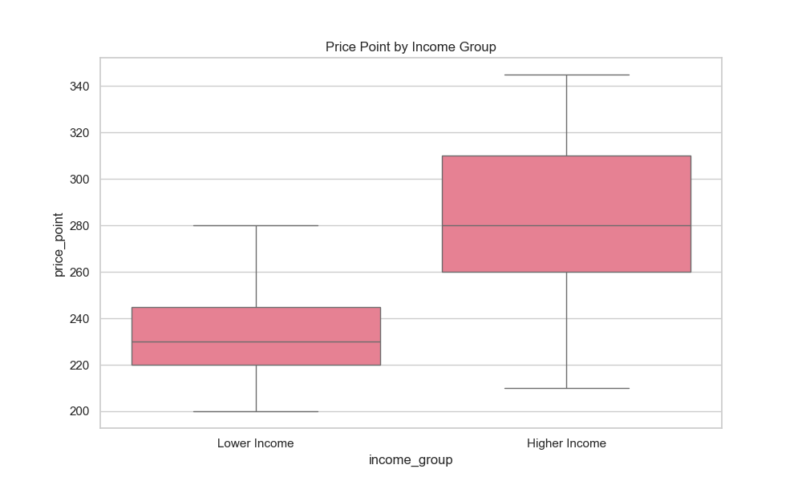

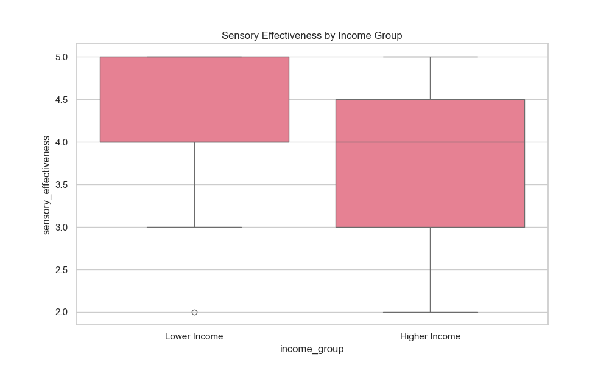

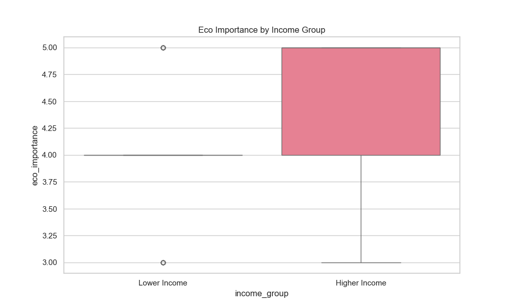

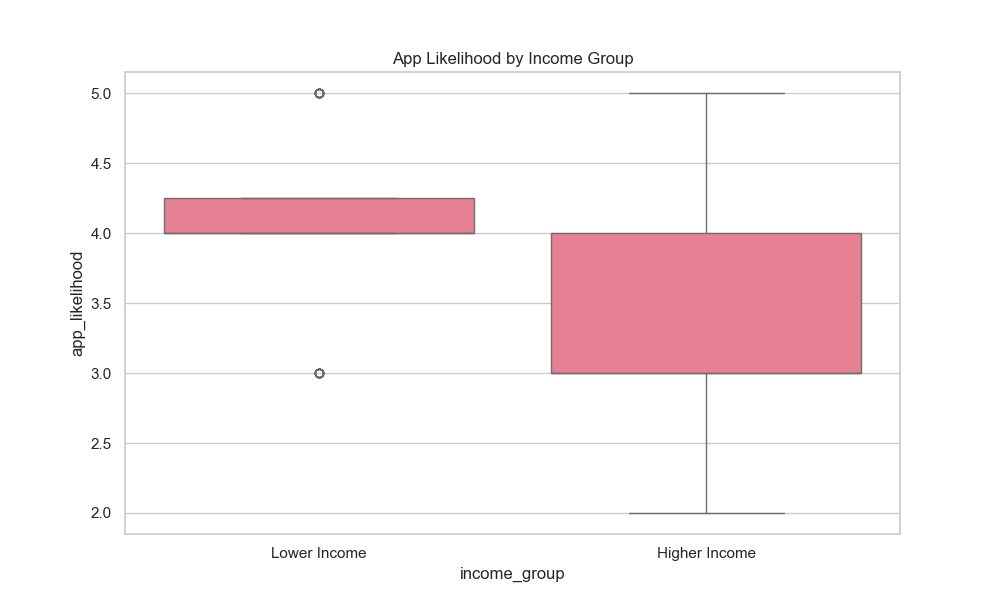

```python
questions = ['price_point', 'eco_importance', 'sensory_effectiveness', 'app_likelihood']
results_pet_experience = {}

for question in questions:
    group1 = merged_df[merged_df['pet_experience'] == 'High'][question]
    group2 = merged_df[merged_df['pet_experience'] != 'High'][question]

    # Perform t-test
    t_stat, p_value = stats.ttest_ind(group1, group2)

    # Calculate means
    means = merged_df.groupby('pet_experience')[question].mean()

    results_pet_experience[question] = {
        'means': means,
        'p_value': p_value,
        't_stat': t_stat
    }

    # Create visualization
    plt.figure(figsize=(10, 6))
    sns.boxplot(x='pet_experience', y=question, data=merged_df)
    plt.title(f'{question.replace("_", " ").title()} by Pet Ownership Experience')
    plt.savefig(f'{question}_experience.png')
    plt.close()

print("\nPet Ownership Experience Analysis:")
for question, result in results_pet_experience.items():
    print(f"\n{question.replace('_', ' ').title()}:")
    print(f"Means by group:\n{result['means']}")
    print(f"P-value: {result['p_value']:.4f}")
    print(f"Statistically significant at 0.05 level: {result['p_value'] < 0.05}")
```

```
Pet Ownership Experience Analysis:

Price Point:
Means by group:
pet_experience
High        255.147059
Low         272.037037
Moderate    249.705882
Name: price_point, dtype: float64
P-value: 0.5703
Statistically significant at 0.05 level: False

Eco Importance:
Means by group:
pet_experience
High        4.176471
Low         4.074074
Moderate    4.352941
Name: eco_importance, dtype: float64
P-value: 0.7355
Statistically significant at 0.05 level: False

Sensory Effectiveness:
Means by group:
pet_experience
High        4.352941
Low         4.000000
Moderate    3.676471
Name: sensory_effectiveness, dtype: float64
P-value: 0.0016
Statistically significant at 0.05 level: True

App Likelihood:
Means by group:
pet_experience
High        4.235294
Low         3.666667
Moderate    3.588235
Name: app_likelihood, dtype: float64
P-value: 0.0002
Statistically significant at 0.05 level: True
```

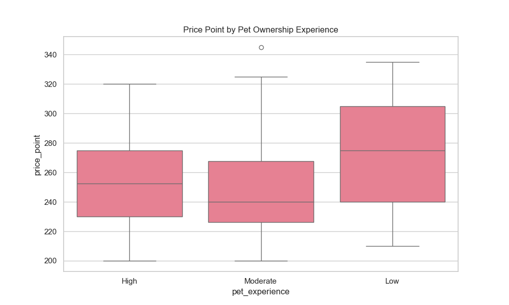

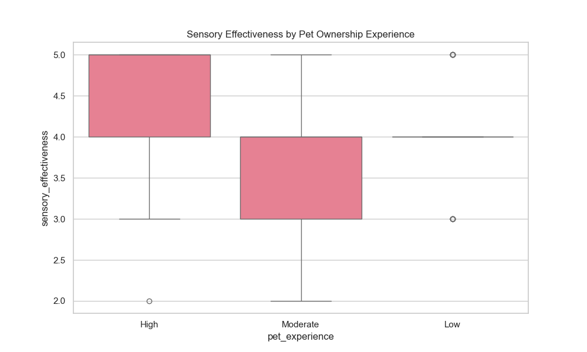

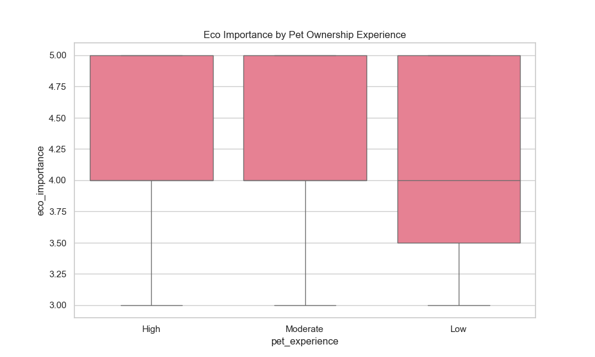

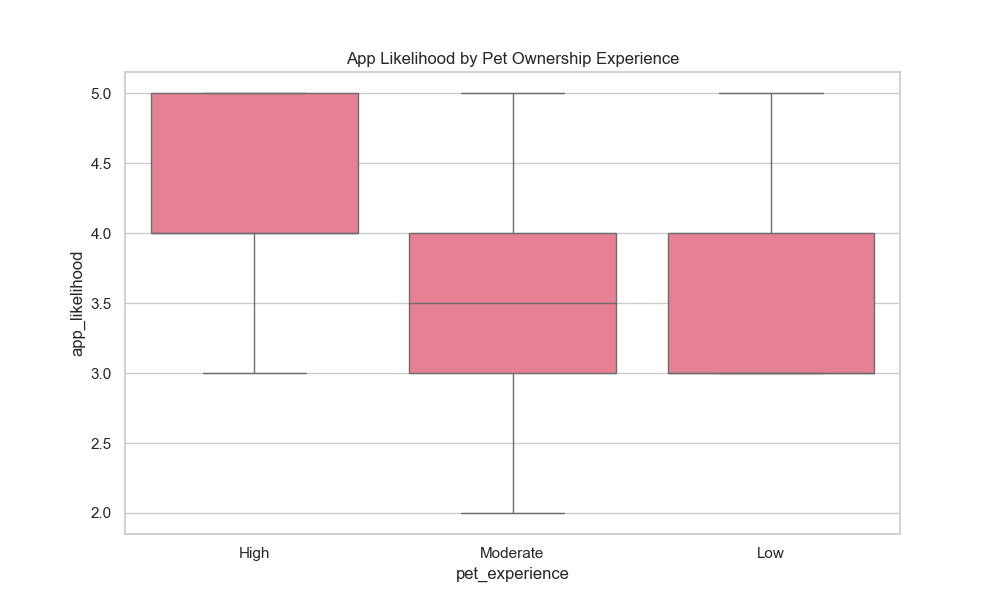